# earthquake: Visualizing NOAA’s Significant Earthquakes

ZIDA

2019-04-01

The `earthquake` package is a small R package for cleaning, timelining, and mapping [NOAA Significant Earthquake data](https://www.ngdc.noaa.gov/nndc/struts/form?t=101650&s=1&d=1). This R package was built to satisfy the requirements of the Capstone project for the [Coursera](http://www.coursera.org) [Mastering Software Development in R](https://www.coursera.org/specializations/r) 5-course specialization.

## Installing earthquake

To install the `earthquake` package, the user must install the `devtools` package. Then, to download and install the `earthquakr` package, use the following commands:

```r
devtools::install_github('DYZI/Earthquake')
library(earthquake)
```

## Necessary Packages

To work through these examples, the following packages need to be installed and loaded:

```r
library(earthquake)
library(dplyr)
library(ggplot2)
library(readr)
library(lubridate)
```

## Loading Data

### Load and Clean Package Data

To load the `quakes` data, simply use the `earthquake::quakes` command (the `earthquake::` invocation is necessary because R comes loaded with another data set called `quakes`).

Then call the `eq_clean_data` and `eq_location` clean command to “clean” some of the variables in the data set for use with the visualization tools in this package. The usage of these commands, plus the “tail” of the data set, are shown below.

```r
quakes <- earthquake::quakes # loads quakes data with data set
quakes <- quakes %>%
  eq_clean_data() %>%
  eq_location_clean()
tail(quakes)
```

```
## # A tibble: 6 × 48
##     I_D FLAG_TSUNAMI  YEAR MONTH   DAY  HOUR MINUTE SECOND FOCAL_DEPTH
##   <int>        <chr> <int> <dbl> <dbl> <int>  <int>  <chr>       <int>
## 1 10227         <NA>  2017     1     6     2     33   29.0          10
## 2 10234         <NA>  2017     1    18    10     14   11.0           7
## 3 10235          Tsu  2017     1    22     4     30   56.0         136
## 4 10237         <NA>  2017     2     7    22      3   56.0          26
## 5 10238         <NA>  2017     2    10    14      3   43.0          15
## 6 10239         <NA>  2017     3    13    14     19    6.0          10
## # ... with 39 more variables: EQ_PRIMARY <dbl>, EQ_MAG_MW <chr>,
## #   EQ_MAG_MS <chr>, EQ_MAG_MB <chr>, EQ_MAG_ML <dbl>, EQ_MAG_MFA <chr>,
## #   EQ_MAG_UNK <chr>, INTENSITY <int>, COUNTRY <chr>, STATE <chr>,
## #   LOCATION_NAME <chr>, LATITUDE <dbl>, LONGITUDE <dbl>,
## #   REGION_CODE <int>, DEATHS <dbl>, DEATHS_DESCRIPTION <int>,
## #   MISSING <chr>, MISSING_DESCRIPTION <int>, INJURIES <chr>,
## #   INJURIES_DESCRIPTION <int>, DAMAGE_MILLIONS_DOLLARS <chr>,
## #   DAMAGE_DESCRIPTION <int>, HOUSES_DESTROYED <int>,
## #   HOUSES_DESTROYED_DESCRIPTION <int>, HOUSES_DAMAGED <int>,
## #   HOUSES_DAMAGED_DESCRIPTION <int>, TOTAL_DEATHS <dbl>,
## #   TOTAL_DEATHS_DESCRIPTION <int>, TOTAL_MISSING <chr>,
## #   TOTAL_MISSING_DESCRIPTION <chr>, TOTAL_INJURIES <int>,
## #   TOTAL_INJURIES_DESCRIPTION <int>, TOTAL_DAMAGE_MILLIONS_DOLLARS <chr>,
## #   TOTAL_DAMAGE_DESCRIPTION <int>, TOTAL_HOUSES_DESTROYED <int>,
## #   TOTAL_HOUSES_DESTROYED_DESCRIPTION <int>, TOTAL_HOUSES_DAMAGED <int>,
## #   TOTAL_HOUSES_DAMAGED_DESCRIPTION <int>, DATE <date>
```

### Single Step, Using Package Data

To save a couple steps of command typing, the `eq_load_clean_data` command will load the `quakes` data and do the cleaning steps all with a single command call:

```r
quakes <- eq_load_clean_data()
tail(quakes)
```

```
## # A tibble: 6 × 48
##     I_D FLAG_TSUNAMI  YEAR MONTH   DAY  HOUR MINUTE SECOND FOCAL_DEPTH
##   <int>        <chr> <int> <dbl> <dbl> <int>  <int>  <chr>       <int>
## 1 10227         <NA>  2017     1     6     2     33   29.0          10
## 2 10234         <NA>  2017     1    18    10     14   11.0           7
## 3 10235          Tsu  2017     1    22     4     30   56.0         136
## 4 10237         <NA>  2017     2     7    22      3   56.0          26
## 5 10238         <NA>  2017     2    10    14      3   43.0          15
## 6 10239         <NA>  2017     3    13    14     19    6.0          10
## # ... with 39 more variables: EQ_PRIMARY <dbl>, EQ_MAG_MW <chr>,
## #   EQ_MAG_MS <chr>, EQ_MAG_MB <chr>, EQ_MAG_ML <dbl>, EQ_MAG_MFA <chr>,
## #   EQ_MAG_UNK <chr>, INTENSITY <int>, COUNTRY <chr>, STATE <chr>,
## #   LOCATION_NAME <chr>, LATITUDE <dbl>, LONGITUDE <dbl>,
## #   REGION_CODE <int>, DEATHS <dbl>, DEATHS_DESCRIPTION <int>,
## #   MISSING <chr>, MISSING_DESCRIPTION <int>, INJURIES <chr>,
## #   INJURIES_DESCRIPTION <int>, DAMAGE_MILLIONS_DOLLARS <chr>,
## #   DAMAGE_DESCRIPTION <int>, HOUSES_DESTROYED <int>,
## #   HOUSES_DESTROYED_DESCRIPTION <int>, HOUSES_DAMAGED <int>,
## #   HOUSES_DAMAGED_DESCRIPTION <int>, TOTAL_DEATHS <dbl>,
## #   TOTAL_DEATHS_DESCRIPTION <int>, TOTAL_MISSING <chr>,
## #   TOTAL_MISSING_DESCRIPTION <chr>, TOTAL_INJURIES <int>,
## #   TOTAL_INJURIES_DESCRIPTION <int>, TOTAL_DAMAGE_MILLIONS_DOLLARS <chr>,
## #   TOTAL_DAMAGE_DESCRIPTION <int>, TOTAL_HOUSES_DESTROYED <int>,
## #   TOTAL_HOUSES_DESTROYED_DESCRIPTION <int>, TOTAL_HOUSES_DAMAGED <int>,
## #   TOTAL_HOUSES_DAMAGED_DESCRIPTION <int>, DATE <date>
```

### Load and Clean Downloaded Data

If you wish to use NOAA Significant Earthquake data updated after April 1, 2019, please visit the NOAA Significant Earthquakes site at https://www.ngdc.noaa.gov/nndc/struts/form?t=101650&s=1&d=1 and download the data to your working directory. Then you may load and clean data for analysis using the following sequence of commands (replace `filename` with the location of your file):

```r
filename <- system.file('extdata', 'earthquakes.txt', package = 'earthquakr')
quakes_from_raw <- readr::read_delim(filename, delim = '\t')
quakes_from_raw_clean <- quakes_from_raw %>%
  eq_clean_data() %>%
  eq_location_clean()
tail(quakes_from_raw_clean)
```

```
## # A tibble: 6 × 48
##     I_D FLAG_TSUNAMI  YEAR MONTH   DAY  HOUR MINUTE SECOND FOCAL_DEPTH
##   <int>        <chr> <int> <dbl> <dbl> <int>  <int>  <chr>       <int>
## 1 10227         <NA>  2017     1     6     2     33   29.0          10
## 2 10234         <NA>  2017     1    18    10     14   11.0           7
## 3 10235          Tsu  2017     1    22     4     30   56.0         136
## 4 10237         <NA>  2017     2     7    22      3   56.0          26
## 5 10238         <NA>  2017     2    10    14      3   43.0          15
## 6 10239         <NA>  2017     3    13    14     19    6.0          10
## # ... with 39 more variables: EQ_PRIMARY <dbl>, EQ_MAG_MW <chr>,
## #   EQ_MAG_MS <chr>, EQ_MAG_MB <chr>, EQ_MAG_ML <dbl>, EQ_MAG_MFA <chr>,
## #   EQ_MAG_UNK <chr>, INTENSITY <int>, COUNTRY <chr>, STATE <chr>,
## #   LOCATION_NAME <chr>, LATITUDE <dbl>, LONGITUDE <dbl>,
## #   REGION_CODE <int>, DEATHS <dbl>, DEATHS_DESCRIPTION <int>,
## #   MISSING <chr>, MISSING_DESCRIPTION <int>, INJURIES <chr>,
## #   INJURIES_DESCRIPTION <int>, DAMAGE_MILLIONS_DOLLARS <chr>,
## #   DAMAGE_DESCRIPTION <int>, HOUSES_DESTROYED <int>,
## #   HOUSES_DESTROYED_DESCRIPTION <int>, HOUSES_DAMAGED <int>,
## #   HOUSES_DAMAGED_DESCRIPTION <int>, TOTAL_DEATHS <dbl>,
## #   TOTAL_DEATHS_DESCRIPTION <int>, TOTAL_MISSING <chr>,
## #   TOTAL_MISSING_DESCRIPTION <chr>, TOTAL_INJURIES <int>,
## #   TOTAL_INJURIES_DESCRIPTION <int>, TOTAL_DAMAGE_MILLIONS_DOLLARS <chr>,
## #   TOTAL_DAMAGE_DESCRIPTION <int>, TOTAL_HOUSES_DESTROYED <int>,
## #   TOTAL_HOUSES_DESTROYED_DESCRIPTION <int>, TOTAL_HOUSES_DAMAGED <int>,
## #   TOTAL_HOUSES_DAMAGED_DESCRIPTION <int>, DATE <date>
```

## Plot Timeline of Data

This package includes a “timeline” capability to visualize countries’ significant earthquakes. The timeline, which is a `ggplot2` geom called `geom_timeline`, when used correctly shows the timeline of a country’s significant earthquakes, with points colored and sized by number of deaths and Richter scale strength, respectively. The timeline plots years on the x-axis and any number of countries stacked on the y-axis.

There is a second `ggplot2` geom in this package, called `geom_timeline_label`, that will label the strongest earthquakes on the timeline for each country.

Additionally, a `ggplot2` theme, `theme_eq`, is provided with this package, which will make your charts much more attractive (in our humble opinion!).

### Timeline Geoms

Load clean data to be used for all charts below:

```r
quakes <- eq_load_clean_data()
```

The following example shows how to make a simple timeline geom for a single country. Notice that the `quakes` data must be filtered by `COUNTRY` and `DATE` variables. For best results, you should use the following `aes = variable` combinations:

- `x = DATE`
- `y = COUNTRY`
- `color = TOTAL_DEATHS`
- `size = EQ_PRIMARY`

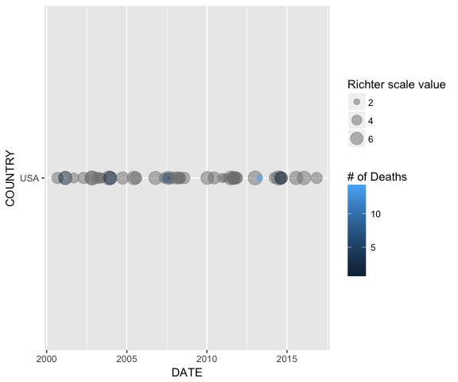

```r
quakes %>%
  dplyr::filter(COUNTRY == 'USA') %>%
  dplyr::filter(DATE > '2000-01-01') %>%
  ggplot() +
  geom_timeline(aes(x = DATE, y = COUNTRY, color = TOTAL_DEATHS,
                    size = EQ_PRIMARY)) +
  scale_size_continuous(name = 'Richter scale value') +
  scale_color_continuous(name = '# of Deaths')
```

To create a basic timeline with two countries, simply change how you filter the `COUNTRY` value:

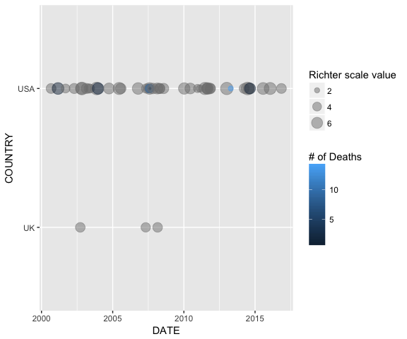

```r
quakes %>%
  dplyr::filter(COUNTRY %in% c('USA', 'UK')) %>%
  dplyr::filter(DATE > '2000-01-01') %>%
  ggplot() +
  geom_timeline(aes(x = DATE, y = COUNTRY, color = TOTAL_DEATHS,
                    size = EQ_PRIMARY)) +
  scale_size_continuous(name = 'Richter scale value') +
  scale_color_continuous(name = '# of Deaths')
```

### Timeline and Label Geoms

To add labels to the timelines, use the `geom_timeline_label` geom with the following `aes = variable` combinations:

- `x = DATE`
- `y = COUNTRY`
- `magnitude = EQ_PRIMARY`
- `label = LOCATION_NAME`
- `n_max = <integer, suggest 5>`

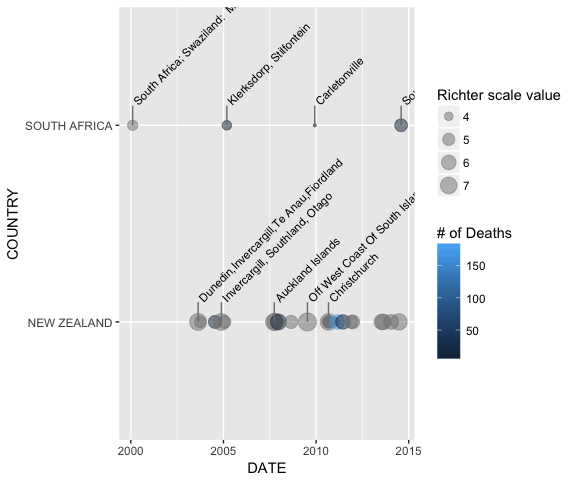

```r
quakes %>%
  dplyr::filter(COUNTRY %in% c('NEW ZEALAND', 'SOUTH AFRICA')) %>%
  dplyr::filter(DATE > '2000-01-01', DATE < '2015-01-01') %>%
  ggplot() +
  geom_timeline(aes(x = DATE, y = COUNTRY, color = TOTAL_DEATHS,
                    size = EQ_PRIMARY)) +
  geom_timeline_label(aes(x = DATE, y = COUNTRY, magnitude = EQ_PRIMARY,
                         label = LOCATION_NAME, n_max = 5)) +
  scale_size_continuous(name = 'Richter scale value') +
  scale_color_continuous(name = '# of Deaths')
```

### Timeline and Label Geoms with theme_eq

To make the charts look slightly more attractive, use the included `ggplot2` theme: `theme_eq`.

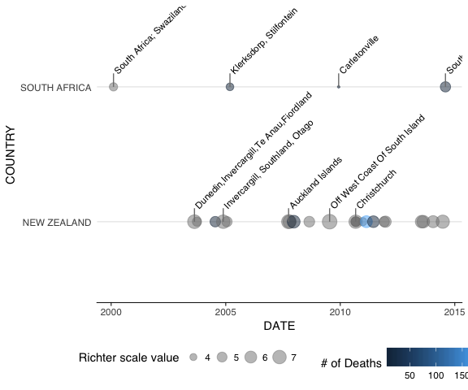

```r
quakes %>%
  dplyr::filter(COUNTRY %in% c('NEW ZEALAND', 'SOUTH AFRICA')) %>%
  dplyr::filter(DATE > '2000-01-01', DATE < '2015-01-01') %>%
  ggplot() +
  geom_timeline(aes(x = DATE, y = COUNTRY, color = TOTAL_DEATHS,
                    size = EQ_PRIMARY)) +
  geom_timeline_label(aes(x = DATE, y = COUNTRY, magnitude = EQ_PRIMARY,
                         label = LOCATION_NAME, n_max = 5)) +
  scale_size_continuous(name = 'Richter scale value') +
  scale_color_continuous(name = '# of Deaths') +
  theme_eq()
```

### Use Wrapper Function for Ease of Use

All the above can be an awful lot of typing to get these charts. So, this package includes a handy `eq_timeline` wrapper function to make a nice labeled (or not!) chart with the default `aes` values and theme selection. This is much easier than typing in all of the above.

#### One Country, No Labels

Here is an example with one country and no labels on the earthquakes.

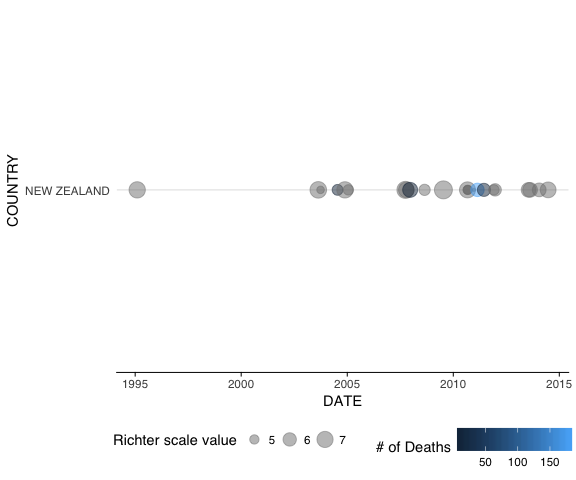

```r
quakes %>% eq_timeline(countries = 'NEW ZEALAND',
                       date_min = as.Date('1995-01-01'),
                       date_max = as.POSIXct('2015-01-01'),
                       label_n = 0)
```

#### Multiple Countries, Labels

Here is an example of multiple countries and up to 5 labels per country.

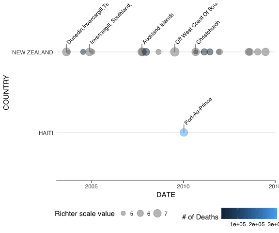

```r
quakes %>% eq_timeline(countries = c('NEW ZEALAND', 'HAITI'),
                       date_min = '2000-01-01',
                       date_max = '2015-01-01',
                       label_n = 5)
```

## Plot Map

Finally, this package includes functions for creating an interactive map of the earthquakes using the `leaflet` package.

### Basic Annotations

Call the `eq_map` function with cleaned and filtered data, and specify an annotation column with the argument `annot_col`:

```r
quakes %>%
  dplyr::filter(COUNTRY == 'JAPAN') %>%
  dplyr::filter(lubridate::year(DATE) >= 2000) %>%
  eq_map(annot_col = 'DATE')
```

[interactive chart not shown]

### More Useful Annotations

If you’d like more useful annotations, first call `quakes <- quakes %>% dplyr::mutate(popup_text = eq_create_label(.))` to create a data column with formatted HTML for more useful quakes information, and then call the `eq_map` function:

```r
quakes %>%
  dplyr::filter(COUNTRY == 'MEXICO') %>%
  dplyr::filter(lubridate::year(DATE) >= 2000) %>%
  dplyr::mutate(popup_text = eq_create_label(.)) %>%
  eq_map(annot_col = 'popup_text')
```

[interactive chart not shown]